# Case Study Two: Exploratory Data Analysis Report

Report by dlookr package - Executed by Zachary Harris

2021-08-07

# 1 Introduction

The EDA Report provides exploratory data analysis information on objects that inherit data.frame and data.frame.

## 1.1 Information of Dataset

The dataset that generated the EDA Report is an **‘data.frame’** object. It consists of **870 observations** and **36 variables**.

## 1.2 Information of Variables

The variable information of the data set that generated the EDA Report is shown in the following table.:

Information of Variables

| variables | types | missing_count | missing_percent | unique_count | unique_rate |
| --- | --- | --- | --- | --- | --- |
| ID | integer | 0 | 0 | 870 | 1.000 |
| Age | integer | 0 | 0 | 43 | 0.049 |
| Attrition | character | 0 | 0 | 2 | 0.002 |
| BusinessTravel | character | 0 | 0 | 3 | 0.003 |
| DailyRate | integer | 0 | 0 | 627 | 0.721 |
| Department | character | 0 | 0 | 3 | 0.003 |
| DistanceFromHome | integer | 0 | 0 | 29 | 0.033 |
| Education | integer | 0 | 0 | 5 | 0.006 |
| EducationField | character | 0 | 0 | 6 | 0.007 |
| EmployeeCount | integer | 0 | 0 | 1 | 0.001 |
| EmployeeNumber | integer | 0 | 0 | 870 | 1.000 |
| EnvironmentSatisfaction | integer | 0 | 0 | 4 | 0.005 |
| Gender | character | 0 | 0 | 2 | 0.002 |
| HourlyRate | integer | 0 | 0 | 71 | 0.082 |
| JobInvolvement | integer | 0 | 0 | 4 | 0.005 |
| JobLevel | integer | 0 | 0 | 5 | 0.006 |
| JobRole | character | 0 | 0 | 9 | 0.010 |
| JobSatisfaction | integer | 0 | 0 | 4 | 0.005 |
| MaritalStatus | character | 0 | 0 | 3 | 0.003 |
| MonthlyIncome | integer | 0 | 0 | 826 | 0.949 |
| MonthlyRate | integer | 0 | 0 | 852 | 0.979 |
| NumCompaniesWorked | integer | 0 | 0 | 10 | 0.011 |
| Over18 | character | 0 | 0 | 1 | 0.001 |
| OverTime | character | 0 | 0 | 2 | 0.002 |
| PercentSalaryHike | integer | 0 | 0 | 15 | 0.017 |
| PerformanceRating | integer | 0 | 0 | 2 | 0.002 |
| RelationshipSatisfaction | integer | 0 | 0 | 4 | 0.005 |
| StandardHours | integer | 0 | 0 | 1 | 0.001 |
| StockOptionLevel | integer | 0 | 0 | 4 | 0.005 |
| TotalWorkingYears | integer | 0 | 0 | 39 | 0.045 |
| TrainingTimesLastYear | integer | 0 | 0 | 7 | 0.008 |
| WorkLifeBalance | integer | 0 | 0 | 4 | 0.005 |
| YearsAtCompany | integer | 0 | 0 | 32 | 0.037 |
| YearsInCurrentRole | integer | 0 | 0 | 19 | 0.022 |
| YearsSinceLastPromotion | integer | 0 | 0 | 16 | 0.018 |
| YearsWithCurrManager | integer | 0 | 0 | 17 | 0.020 |

The target variable of the data is **‘NULL’**, and the data type of the variable is **NULL(You did not specify a target variable)**.

## 1.3 About EDA Report

EDA reports provide information and visualization results that support the EDA process. In particular, it provides a variety of information to understand the relationship between the target variable and the rest of the variables of interest.

# 2 Univariate Analysis

## 2.1 Descriptive Statistics

edaData  
36 Variables 870 Observations

ID

| n | missing | distinct | Info | Mean | Gmd | .05 | .10 | .25 | .50 | .75 | .90 | .95 |
| --- | --- | --- | --- | --- | --- | --- | --- | --- | --- | --- | --- | --- |
| 870 | 0 | 870 | 1 | 435.5 | 290.3 | 44.45 | 87.90 | 218.25 | 435.50 | 652.75 | 783.10 | 826.55 |

lowest : 1 2 3 4 5 , highest: 866 867 868 869 870

Age

| n | missing | distinct | Info | Mean | Gmd | .05 | .10 | .25 | .50 | .75 | .90 | .95 |
| --- | --- | --- | --- | --- | --- | --- | --- | --- | --- | --- | --- | --- |
| 870 | 0 | 43 | 0.999 | 36.83 | 10.07 | 24 | 26 | 30 | 35 | 43 | 50 | 54 |

lowest : 18 19 20 21 22 , highest: 56 57 58 59 60

Attrition

| n | missing | distinct |
| --- | --- | --- |
| 870 | 0 | 2 |

```
 Value         No   Yes
 Frequency    730   140
 Proportion 0.839 0.161
```

BusinessTravel

| n | missing | distinct |
| --- | --- | --- |
| 870 | 0 | 3 |

```
 Value             Non-Travel Travel_Frequently     Travel_Rarely
 Frequency                 94               158               618
 Proportion             0.108             0.182             0.710
```

DailyRate

| n | missing | distinct | Info | Mean | Gmd | .05 | .10 | .25 | .50 | .75 | .90 | .95 |
| --- | --- | --- | --- | --- | --- | --- | --- | --- | --- | --- | --- | --- |
| 870 | 0 | 627 | 1 | 815.2 | 463.3 | 175.4 | 257.8 | 472.5 | 817.5 | 1165.8 | 1368.0 | 1436.7 |

lowest : 103 111 117 119 120 , highest: 1490 1495 1496 1498 1499

Department

| n | missing | distinct |
| --- | --- | --- |
| 870 | 0 | 3 |

```
 Value             Human Resources Research & Development                  Sales
 Frequency                      35                    562                    273
 Proportion                  0.040                  0.646                  0.314
```

DistanceFromHome

| n | missing | distinct | Info | Mean | Gmd | .05 | .10 | .25 | .50 | .75 | .90 | .95 |
| --- | --- | --- | --- | --- | --- | --- | --- | --- | --- | --- | --- | --- |
| 870 | 0 | 29 | 0.993 | 9.339 | 8.843 | 1.0 | 1.0 | 2.0 | 7.0 | 14.0 | 23.1 | 26.0 |

lowest : 1 2 3 4 5 , highest: 25 26 27 28 29

Education

| n | missing | distinct | Info | Mean | Gmd |
| --- | --- | --- | --- | --- | --- |
| 870 | 0 | 5 | 0.917 | 2.901 | 1.12 |

lowest : 1 2 3 4 5 , highest: 1 2 3 4 5

```
 Value          1     2     3     4     5
 Frequency     98   182   324   240    26
 Proportion 0.113 0.209 0.372 0.276 0.030
```

EducationField

| n | missing | distinct |
| --- | --- | --- |
| 870 | 0 | 6 |

| lowest : | Human Resources | Life Sciences | Marketing | Medical | Other |
| --- | --- | --- | --- | --- | --- |
| highest: | Life Sciences | Marketing | Medical | Other | Technical Degree |

```
 Value       Human Resources    Life Sciences        Marketing          Medical
 Frequency                15              358              100              270
 Proportion            0.017            0.411            0.115            0.310

 Value                 Other Technical Degree
 Frequency                52               75
 Proportion            0.060            0.086
```

EmployeeCount

| n | missing | distinct | Info | Mean | Gmd |
| --- | --- | --- | --- | --- | --- |
| 870 | 0 | 1 | 0 | 1 | 0 |

```
 Value        1
 Frequency  870
 Proportion   1
```

EmployeeNumber

| n | missing | distinct | Info | Mean | Gmd | .05 | .10 | .25 | .50 | .75 | .90 | .95 |
| --- | --- | --- | --- | --- | --- | --- | --- | --- | --- | --- | --- | --- |
| 870 | 0 | 870 | 1 | 1030 | 698.6 | 86.9 | 191.1 | 477.2 | 1039.0 | 1561.5 | 1856.2 | 1958.3 |

lowest : 1 4 11 13 14 , highest: 2041 2053 2056 2062 2064

EnvironmentSatisfaction

| n | missing | distinct | Info | Mean | Gmd |
| --- | --- | --- | --- | --- | --- |
| 870 | 0 | 4 | 0.93 | 2.701 | 1.22 |

```
 Value          1     2     3     4
 Frequency    172   178   258   262
 Proportion 0.198 0.205 0.297 0.301
```

Gender

| n | missing | distinct |
| --- | --- | --- |
| 870 | 0 | 2 |

```
 Value      Female   Male
 Frequency     354    516
 Proportion  0.407  0.593
```

HourlyRate

| n | missing | distinct | Info | Mean | Gmd | .05 | .10 | .25 | .50 | .75 | .90 | .95 |
| --- | --- | --- | --- | --- | --- | --- | --- | --- | --- | --- | --- | --- |
| 870 | 0 | 71 | 1 | 65.61 | 23.24 | 34 | 39 | 48 | 66 | 83 | 94 | 97 |

lowest : 30 31 32 33 34 , highest: 96 97 98 99 100

JobInvolvement

| n | missing | distinct | Info | Mean | Gmd |
| --- | --- | --- | --- | --- | --- |
| 870 | 0 | 4 | 0.775 | 2.723 | 0.7042 |

```
 Value          1     2     3     4
 Frequency     47   228   514    81
 Proportion 0.054 0.262 0.591 0.093
```

JobLevel

| n | missing | distinct | Info | Mean | Gmd |
| --- | --- | --- | --- | --- | --- |
| 870 | 0 | 5 | 0.896 | 2.039 | 1.139 |

lowest : 1 2 3 4 5 , highest: 1 2 3 4 5

```
 Value          1     2     3     4     5
 Frequency    329   312   132    60    37
 Proportion 0.378 0.359 0.152 0.069 0.043
```

JobRole

| n | missing | distinct |
| --- | --- | --- |
| 870 | 0 | 9 |

| lowest : | Healthcare Representative | Human Resources | Laboratory Technician | Manager | Manufacturing Director |
| --- | --- | --- | --- | --- | --- |
| highest: | Manufacturing Director | Research Director | Research Scientist | Sales Executive | Sales Representative |

Healthcare Representative (76, 0.087), Human Resources (27, 0.031), Laboratory Technician (153, 0.176), Manager (51, 0.059), Manufacturing Director (87, 0.100), Research Director (51, 0.059), Research Scientist (172, 0.198), Sales Executive (200, 0.230), Sales Representative (53, 0.061)

JobSatisfaction

| n | missing | distinct | Info | Mean | Gmd |
| --- | --- | --- | --- | --- | --- |
| 870 | 0 | 4 | 0.929 | 2.709 | 1.236 |

```
 Value          1     2     3     4
 Frequency    179   166   254   271
 Proportion 0.206 0.191 0.292 0.311
```

MaritalStatus

| n | missing | distinct |
| --- | --- | --- |
| 870 | 0 | 3 |

```
 Value      Divorced  Married   Single
 Frequency       191      410      269
 Proportion    0.220    0.471    0.309
```

MonthlyIncome

| n | missing | distinct | Info | Mean | Gmd | .05 | .10 | .25 | .50 | .75 | .90 | .95 |
| --- | --- | --- | --- | --- | --- | --- | --- | --- | --- | --- | --- | --- |
| 870 | 0 | 826 | 1 | 6390 | 4757 | 2088 | 2279 | 2840 | 4946 | 8182 | 13571 | 17164 |

lowest : 1081 1091 1102 1118 1129 , highest: 19845 19859 19926 19943 19999

MonthlyRate

| n | missing | distinct | Info | Mean | Gmd | .05 | .10 | .25 | .50 | .75 | .90 | .95 |
| --- | --- | --- | --- | --- | --- | --- | --- | --- | --- | --- | --- | --- |
| 870 | 0 | 852 | 1 | 14326 | 8210 | 3456 | 4751 | 8092 | 14074 | 20456 | 24045 | 25541 |

lowest : 2094 2104 2112 2125 2137 , highest: 26862 26933 26959 26968 26997

NumCompaniesWorked

| n | missing | distinct | Info | Mean | Gmd | .05 | .10 | .25 | .50 | .75 | .90 | .95 |
| --- | --- | --- | --- | --- | --- | --- | --- | --- | --- | --- | --- | --- |
| 870 | 0 | 10 | 0.945 | 2.728 | 2.683 | 0 | 0 | 1 | 2 | 4 | 7 | 8 |

lowest : 0 1 2 3 4 , highest: 5 6 7 8 9

```
 Value          0     1     2     3     4     5     6     7     8     9
 Frequency    111   320    74    91    85    43    39    46    28    33
 Proportion 0.128 0.368 0.085 0.105 0.098 0.049 0.045 0.053 0.032 0.038
```

Over18

| n | missing | distinct | value |
| --- | --- | --- | --- |
| 870 | 0 | 1 | Y |

```
 Value        Y
 Frequency  870
 Proportion   1
```

OverTime

| n | missing | distinct |
| --- | --- | --- |
| 870 | 0 | 2 |

```
 Value        No  Yes
 Frequency   618  252
 Proportion 0.71 0.29
```

PercentSalaryHike

| n | missing | distinct | Info | Mean | Gmd | .05 | .10 | .25 | .50 | .75 | .90 | .95 |
| --- | --- | --- | --- | --- | --- | --- | --- | --- | --- | --- | --- | --- |
| 870 | 0 | 15 | 0.988 | 15.2 | 4.047 | 11 | 11 | 12 | 14 | 18 | 21 | 22 |

lowest : 11 12 13 14 15 , highest: 21 22 23 24 25

```
 Value         11    12    13    14    15    16    17    18    19    20    21    22
 Frequency    126   119   123   120    54    43    56    57    40    27    33    30
 Proportion 0.145 0.137 0.141 0.138 0.062 0.049 0.064 0.066 0.046 0.031 0.038 0.034

 Value         23    24    25
 Frequency     17    14    11
 Proportion 0.020 0.016 0.013
```

PerformanceRating

| n | missing | distinct | Info | Mean | Gmd |
| --- | --- | --- | --- | --- | --- |
| 870 | 0 | 2 | 0.386 | 3.152 | 0.2577 |

```
 Value          3     4
 Frequency    738   132
 Proportion 0.848 0.152
```

RelationshipSatisfaction

| n | missing | distinct | Info | Mean | Gmd |
| --- | --- | --- | --- | --- | --- |
| 870 | 0 | 4 | 0.929 | 2.707 | 1.223 |

```
 Value          1     2     3     4
 Frequency    174   171   261   264
 Proportion 0.200 0.197 0.300 0.303
```

StandardHours

| n | missing | distinct | Info | Mean | Gmd |
| --- | --- | --- | --- | --- | --- |
| 870 | 0 | 1 | 0 | 80 | 0 |

```
 Value       80
 Frequency  870
 Proportion   1
```

StockOptionLevel

| n | missing | distinct | Info | Mean | Gmd |
| --- | --- | --- | --- | --- | --- |
| 870 | 0 | 4 | 0.848 | 0.7839 | 0.8749 |

```
 Value          0     1     2     3
 Frequency    379   355    81    55
 Proportion 0.436 0.408 0.093 0.063
```

TotalWorkingYears

| n | missing | distinct | Info | Mean | Gmd | .05 | .10 | .25 | .50 | .75 | .90 | .95 |
| --- | --- | --- | --- | --- | --- | --- | --- | --- | --- | --- | --- | --- |
| 870 | 0 | 39 | 0.995 | 11.05 | 8.048 | 1 | 3 | 6 | 10 | 15 | 22 | 26 |

lowest : 0 1 2 3 4 , highest: 34 35 36 37 40

TrainingTimesLastYear

| n | missing | distinct | Info | Mean | Gmd |
| --- | --- | --- | --- | --- | --- |
| 870 | 0 | 7 | 0.909 | 2.832 | 1.341 |

lowest : 0 1 2 3 4 , highest: 2 3 4 5 6

```
 Value          0     1     2     3     4     5     6
 Frequency     30    39   309   308    73    75    36
 Proportion 0.034 0.045 0.355 0.354 0.084 0.086 0.041
```

WorkLifeBalance

| n | missing | distinct | Info | Mean | Gmd |
| --- | --- | --- | --- | --- | --- |
| 870 | 0 | 4 | 0.759 | 2.782 | 0.7045 |

```
 Value          1     2     3     4
 Frequency     48   192   532    98
 Proportion 0.055 0.221 0.611 0.113
```

YearsAtCompany

| n | missing | distinct | Info | Mean | Gmd | .05 | .10 | .25 | .50 | .75 | .90 | .95 |
| --- | --- | --- | --- | --- | --- | --- | --- | --- | --- | --- | --- | --- |
| 870 | 0 | 32 | 0.993 | 6.962 | 6.208 | 1 | 1 | 3 | 5 | 10 | 15 | 20 |

lowest : 0 1 2 3 4 , highest: 30 31 32 33 40

YearsInCurrentRole

| n | missing | distinct | Info | Mean | Gmd | .05 | .10 | .25 | .50 | .75 | .90 | .95 |
| --- | --- | --- | --- | --- | --- | --- | --- | --- | --- | --- | --- | --- |
| 870 | 0 | 19 | 0.973 | 4.205 | 3.967 | 0 | 0 | 2 | 3 | 7 | 9 | 11 |

lowest : 0 1 2 3 4 , highest: 14 15 16 17 18

```
 Value          0     1     2     3     4     5     6     7     8     9    10    11
 Frequency    151    38   223    68    53    26    17   136    56    40    14    15
 Proportion 0.174 0.044 0.256 0.078 0.061 0.030 0.020 0.156 0.064 0.046 0.016 0.017

 Value         12    13    14    15    16    17    18
 Frequency      7     9     7     3     3     3     1
 Proportion 0.008 0.010 0.008 0.003 0.003 0.003 0.001
```

YearsSinceLastPromotion

| n | missing | distinct | Info | Mean | Gmd | .05 | .10 | .25 | .50 | .75 | .90 | .95 |
| --- | --- | --- | --- | --- | --- | --- | --- | --- | --- | --- | --- | --- |
| 870 | 0 | 16 | 0.923 | 2.169 | 2.961 | 0 | 0 | 0 | 1 | 3 | 7 | 9 |

lowest : 0 1 2 3 4 , highest: 11 12 13 14 15

```
 Value          0     1     2     3     4     5     6     7     8     9    10    11
 Frequency    342   214    94    32    32    30    23    41    12     9     4    14
 Proportion 0.393 0.246 0.108 0.037 0.037 0.034 0.026 0.047 0.014 0.010 0.005 0.016

 Value         12    13    14    15
 Frequency      5     5     5     8
 Proportion 0.006 0.006 0.006 0.009
```

YearsWithCurrManager

| n | missing | distinct | Info | Mean | Gmd | .05 | .10 | .25 | .50 | .75 | .90 | .95 |
| --- | --- | --- | --- | --- | --- | --- | --- | --- | --- | --- | --- | --- |
| 870 | 0 | 17 | 0.976 | 4.14 | 3.938 | 0 | 0 | 2 | 3 | 7 | 9 | 10 |

lowest : 0 1 2 3 4 , highest: 12 13 14 15 17

```
 Value          0     1     2     3     4     5     6     7     8     9    10    11
 Frequency    166    40   202    76    51    22    12   131    68    44    18    11
 Proportion 0.191 0.046 0.232 0.087 0.059 0.025 0.014 0.151 0.078 0.051 0.021 0.013

 Value         12    13    14    15    17
 Frequency     13     7     4     1     4
 Proportion 0.015 0.008 0.005 0.001 0.005
```

## 2.2 Normality Test of Numerical Variables

### 2.2.1 Statistics and Visualization of (Sample) Data

**[ ID ]**

normality test : Shapiro-Wilk normality test

```
 statistic : 0.95479,  p-value : 1.03505E-15
```

skewness and kurtosis

| type | skewness | kurtosis |
| --- | --- | --- |
| original | 0.0000000 | 1.799997 |
| log transformation | -1.8417949 | 7.423259 |
| sqrt transformation | -0.5617971 | 2.389436 |

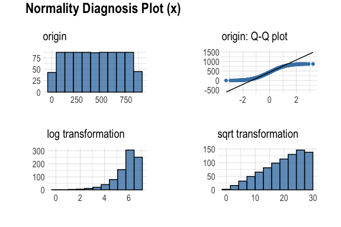

**[ Age ]**

normality test : Shapiro-Wilk normality test

```
 statistic : 0.97885,  p-value : 6.52264E-10
```

skewness and kurtosis

| type | skewness | kurtosis |
| --- | --- | --- |
| original | 0.4192722 | 2.696195 |
| log transformation | -0.1765591 | 2.800833 |
| sqrt transformation | 0.1341646 | 2.626806 |

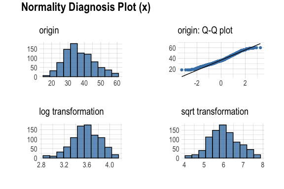

**[ DailyRate ]**

normality test : Shapiro-Wilk normality test

```
 statistic : 0.95626,  p-value : 1.98654E-15
```

skewness and kurtosis

| type | skewness | kurtosis |
| --- | --- | --- |
| original | -0.0301751 | 1.819336 |
| log transformation | -0.9486325 | 3.096908 |
| sqrt transformation | -0.4315904 | 2.139286 |

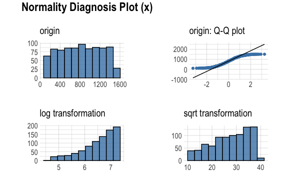

**[ DistanceFromHome ]**

normality test : Shapiro-Wilk normality test

```
 statistic : 0.86501,  p-value : 1.0735E-26
```

skewness and kurtosis

| type | skewness | kurtosis |
| --- | --- | --- |
| original | 0.9139198 | 2.654459 |
| log transformation | -0.2550292 | 1.878048 |
| sqrt transformation | 0.3758469 | 1.978015 |

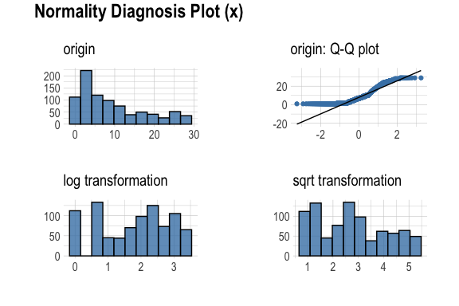

**[ Education ]**

normality test : Shapiro-Wilk normality test

```
 statistic : 0.89657,  p-value : 9.80691E-24
```

skewness and kurtosis

| type | skewness | kurtosis |
| --- | --- | --- |
| original | -0.2660953 | 2.371450 |
| log transformation | -1.0675094 | 3.372744 |
| sqrt transformation | -0.6617993 | 2.716920 |

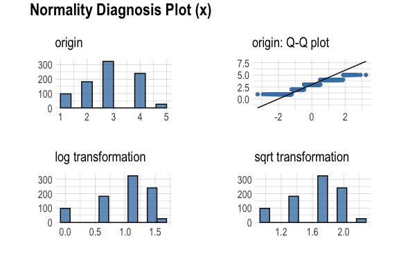

**[ EmployeeNumber ]**

normality test : Shapiro-Wilk normality test

```
 statistic : 0.95008,  p-value : 1.40227E-16
```

skewness and kurtosis

| type | skewness | kurtosis |
| --- | --- | --- |
| original | -0.0316632 | 1.763814 |
| log transformation | -1.8186470 | 7.319087 |
| sqrt transformation | -0.5763380 | 2.327812 |

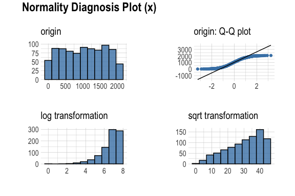

**[ EnvironmentSatisfaction ]**

normality test : Shapiro-Wilk normality test

```
 statistic : 0.85029,  p-value : 6.75708E-28
```

skewness and kurtosis

| type | skewness | kurtosis |
| --- | --- | --- |
| original | -0.2834738 | 1.759659 |
| log transformation | -0.7744284 | 2.231253 |
| sqrt transformation | -0.5287789 | 1.961482 |

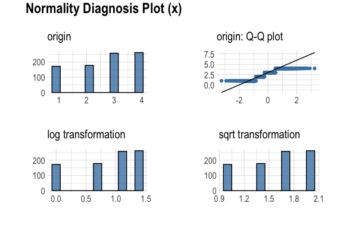

**[ HourlyRate ]**

normality test : Shapiro-Wilk normality test

```
 statistic : 0.95517,  p-value : 1.22133E-15
```

skewness and kurtosis

| type | skewness | kurtosis |
| --- | --- | --- |
| original | 0.0088308 | 1.796513 |
| log transformation | -0.4064573 | 2.069234 |
| sqrt transformation | -0.1908991 | 1.875531 |

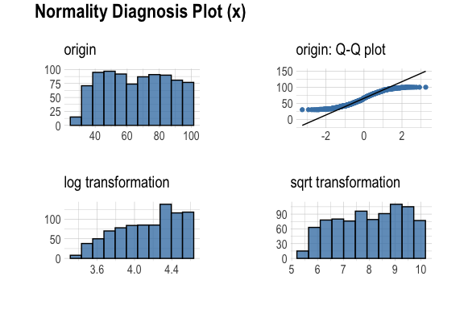

**[ JobInvolvement ]**

normality test : Shapiro-Wilk normality test

```
 statistic : 0.80738,  p-value : 6.15292E-31
```

skewness and kurtosis

| type | skewness | kurtosis |
| --- | --- | --- |
| original | -0.4857346 | 3.266252 |
| log transformation | -1.4603772 | 5.394909 |
| sqrt transformation | -0.9513390 | 4.013176 |

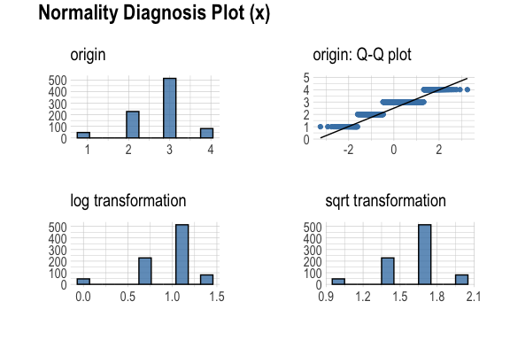

**[ JobLevel ]**

normality test : Shapiro-Wilk normality test

```
 statistic : 0.82062,  p-value : 4.62242E-30
```

skewness and kurtosis

| type | skewness | kurtosis |
| --- | --- | --- |
| original | 1.0318164 | 3.448529 |
| log transformation | 0.2303559 | 1.898326 |
| sqrt transformation | 0.5986293 | 2.493077 |

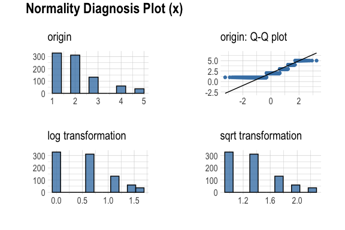

**[ JobSatisfaction ]**

normality test : Shapiro-Wilk normality test

```
 statistic : 0.84458,  p-value : 2.44591E-28
```

skewness and kurtosis

| type | skewness | kurtosis |
| --- | --- | --- |
| original | -0.3026563 | 1.735115 |
| log transformation | -0.7684284 | 2.173673 |
| sqrt transformation | -0.5366526 | 1.925971 |

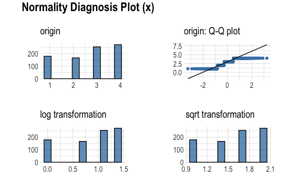

**[ MonthlyIncome ]**

normality test : Shapiro-Wilk normality test

```
 statistic : 0.83195,  p-value : 2.85664E-29
```

skewness and kurtosis

| type | skewness | kurtosis |
| --- | --- | --- |
| original | 1.3879353 | 4.147190 |
| log transformation | 0.2728500 | 2.290551 |
| sqrt transformation | 0.8557648 | 2.924987 |

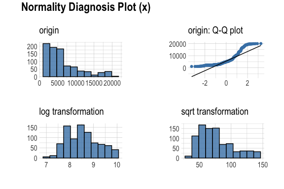

**[ MonthlyRate ]**

normality test : Shapiro-Wilk normality test

```
 statistic : 0.9549,  p-value : 1.08301E-15
```

skewness and kurtosis

| type | skewness | kurtosis |
| --- | --- | --- |
| original | 0.0406756 | 1.791115 |
| log transformation | -0.8120327 | 2.808685 |
| sqrt transformation | -0.3333737 | 2.014415 |

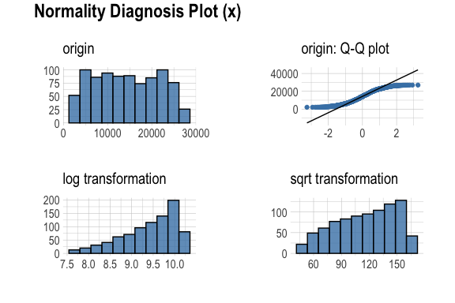

**[ NumCompaniesWorked ]**

normality test : Shapiro-Wilk normality test

```
 statistic : 0.84746,  p-value : 4.06852E-28
```

skewness and kurtosis

| type | skewness | kurtosis |
| --- | --- | --- |
| original | 1.0033200 | 2.937600 |
| log+1 transformation | 0.0994496 | 2.049875 |
| sqrt transformation | 0.0396995 | 2.345212 |

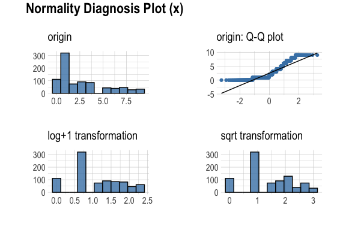

**[ PercentSalaryHike ]**

normality test : Shapiro-Wilk normality test

```
 statistic : 0.89909,  p-value : 1.8054E-23
```

skewness and kurtosis

| type | skewness | kurtosis |
| --- | --- | --- |
| original | 0.8316308 | 2.723658 |
| log transformation | 0.5024206 | 2.179809 |
| sqrt transformation | 0.6643807 | 2.414022 |

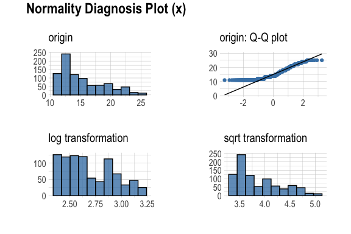

**[ PerformanceRating ]**

normality test : Shapiro-Wilk normality test

```
 statistic : 0.42874,  p-value : 5.85354E-46
```

skewness and kurtosis

| type | skewness | kurtosis |
| --- | --- | --- |
| original | 1.94159 | 4.769771 |
| log transformation | 1.94159 | 4.769771 |
| sqrt transformation | 1.94159 | 4.769771 |

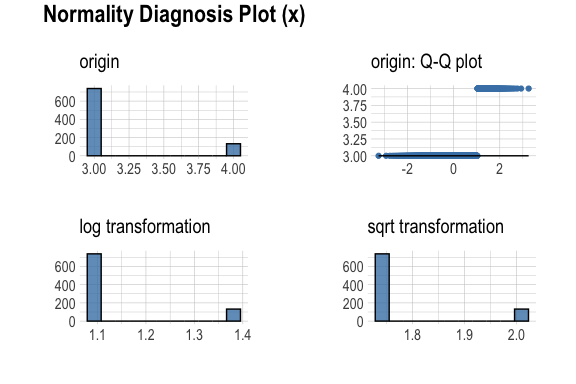

**[ RelationshipSatisfaction ]**

normality test : Shapiro-Wilk normality test

```
 statistic : 0.84828,  p-value : 4.7115E-28
```

skewness and kurtosis

| type | skewness | kurtosis |
| --- | --- | --- |
| original | -0.2992782 | 1.762138 |
| log transformation | -0.7820318 | 2.224820 |
| sqrt transformation | -0.5414741 | 1.961763 |

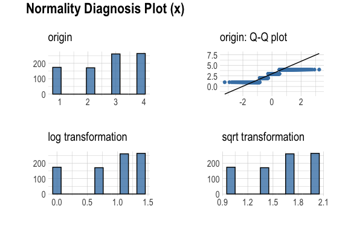

**[ StockOptionLevel ]**

normality test : Shapiro-Wilk normality test

```
 statistic : 0.78052,  p-value : 1.40766E-32
```

skewness and kurtosis

| type | skewness | kurtosis |
| --- | --- | --- |
| original | 1.0312937 | 3.506321 |
| log+1 transformation | 0.3130628 | 1.902057 |
| sqrt transformation | 0.0933208 | 1.540594 |

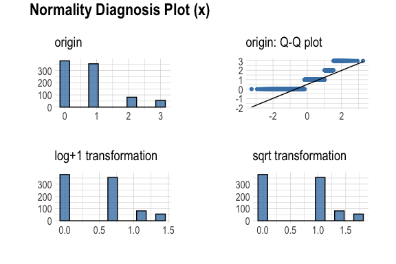

**[ TotalWorkingYears ]**

normality test : Shapiro-Wilk normality test

```
 statistic : 0.90948,  p-value : 2.53635E-22
```

skewness and kurtosis

| type | skewness | kurtosis |
| --- | --- | --- |
| original | 1.1358087 | 4.099248 |
| log+1 transformation | -0.6696374 | 3.607501 |
| sqrt transformation | 0.1398037 | 3.087053 |

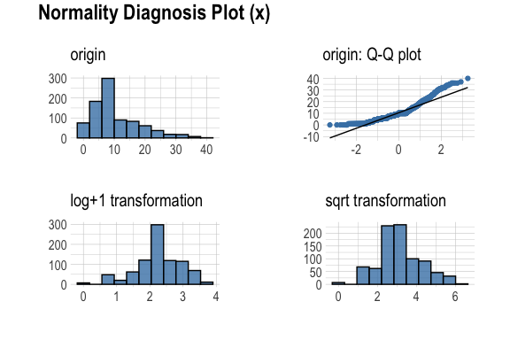

**[ TrainingTimesLastYear ]**

normality test : Shapiro-Wilk normality test

```
 statistic : 0.89638,  p-value : 9.36416E-24
```

skewness and kurtosis

| type | skewness | kurtosis |
| --- | --- | --- |
| original | 0.5176468 | 3.484979 |
| log+1 transformation | -1.1191524 | 6.007159 |
| sqrt transformation | -1.2569059 | 6.953591 |

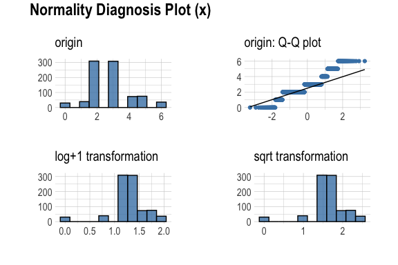

**[ WorkLifeBalance ]**

normality test : Shapiro-Wilk normality test

```
 statistic : 0.80109,  p-value : 2.45129E-31
```

skewness and kurtosis

| type | skewness | kurtosis |
| --- | --- | --- |
| original | -0.5753104 | 3.463191 |
| log transformation | -1.5834352 | 5.764754 |
| sqrt transformation | -1.0629116 | 4.311601 |

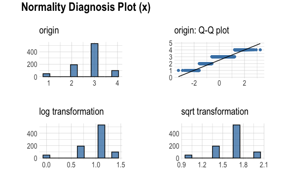

**[ YearsAtCompany ]**

normality test : Shapiro-Wilk normality test

```
 statistic : 0.85504,  p-value : 1.60823E-27
```

skewness and kurtosis

| type | skewness | kurtosis |
| --- | --- | --- |
| original | 1.6263119 | 6.378029 |
| log+1 transformation | -0.2316045 | 2.584796 |
| sqrt transformation | 0.3437876 | 3.155264 |

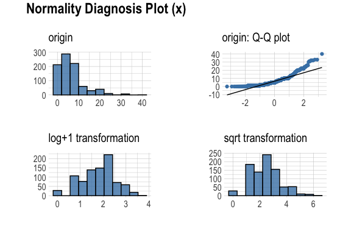

**[ YearsInCurrentRole ]**

normality test : Shapiro-Wilk normality test

```
 statistic : 0.89509,  p-value : 6.89824E-24
```

skewness and kurtosis

| type | skewness | kurtosis |
| --- | --- | --- |
| original | 0.8749995 | 3.318296 |
| log+1 transformation | -0.3607673 | 2.127338 |
| sqrt transformation | -0.2449606 | 2.271939 |

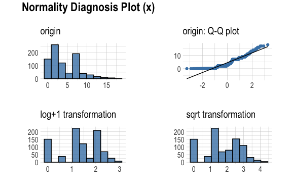

**[ YearsSinceLastPromotion ]**

normality test : Shapiro-Wilk normality test

```
 statistic : 0.70474,  p-value : 1.8024E-36
```

skewness and kurtosis

| type | skewness | kurtosis |
| --- | --- | --- |
| original | 1.9966663 | 6.727089 |
| log+1 transformation | 0.7138531 | 2.400242 |
| sqrt transformation | 0.7318282 | 2.656006 |

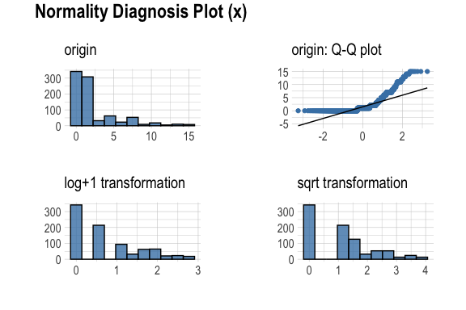

**[ YearsWithCurrManager ]**

normality test : Shapiro-Wilk normality test

```
 statistic : 0.89891,  p-value : 1.72805E-23
```

skewness and kurtosis

| type | skewness | kurtosis |
| --- | --- | --- |
| original | 0.7305582 | 2.858347 |
| log+1 transformation | -0.3665943 | 2.009340 |
| sqrt transformation | -0.2784825 | 2.119743 |

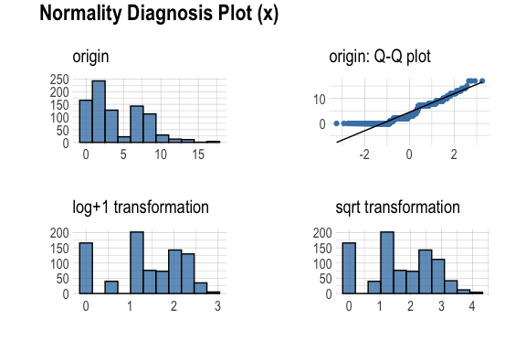

# 3 Relationship Between Variables

## 3.1 Correlation Coefficient

### 3.1.1 Correlation Coefficient by Variable Combination

Table of correlation coefficients (0.5 or more)

| Variable1 | Variable2 | Correlation Coefficient |
| --- | --- | --- |
| MonthlyIncome | JobLevel | 0.9516400 |
| TotalWorkingYears | JobLevel | 0.7807524 |
| TotalWorkingYears | MonthlyIncome | 0.7785112 |
| YearsInCurrentRole | YearsAtCompany | 0.7761164 |
| PerformanceRating | PercentSalaryHike | 0.7750532 |
| YearsWithCurrManager | YearsAtCompany | 0.7652262 |
| YearsWithCurrManager | YearsInCurrentRole | 0.7094612 |
| TotalWorkingYears | Age | 0.6526131 |
| YearsSinceLastPromotion | YearsAtCompany | 0.6440298 |
| YearsAtCompany | TotalWorkingYears | 0.6360836 |
| YearsSinceLastPromotion | YearsInCurrentRole | 0.5537100 |
| YearsAtCompany | JobLevel | 0.5205835 |
| YearsWithCurrManager | YearsSinceLastPromotion | 0.5089354 |

### 3.1.2 Correlation Plot of Numerical Variables

[figure not shown]

# 4 Target based Analysis

## 4.1 Grouped Descriptive Statistics

### 4.1.1 Grouped Numerical Variables

There is no target variable.

### 4.1.2 Grouped Categorical Variables

There is no target variable.

## 4.2 Grouped Relationship Between Variables

### 4.2.1 Grouped Correlation Coefficient

```
There is no target variable.
```

### 4.2.2 Grouped Correlation Plot of Numerical Variables

```
There is no target variable.
```